# Bayesian prediction of probability of victory for a given player in ATP tennis

J. Alberto Márquez Luján

23-05-2023

## ATP Data

The data was obtained from [Kaggle](https://www.kaggle.com/datasets/dissfya/atp-tennis-2013-2023?resource=download). This dataframe, as explained in the Data Card, contains information about every tennis match from 2013 to 2023 in male singles. It was downloaded on 07-05-2023.

Our objective is to choose a player and analyze his games to see if there are factors that can lead us to determine a certain probability that he will win the match. Since we are talking about guessing the outcome of a match, we have to keep in mind that it will be very difficult to obtain a perfect model, but at least we can hope to gain some insights as to what conditions may help the given player.

## Choosing the player

We begin by examining the downloaded data:

```r
rm(list=ls())

atp = read.csv('atp_tennis.csv')
head(atp)
```

```
##               Tournament       Date Series   Court Surface     Round Best.of
## 1 Brisbane International 2012-12-31 ATP250 Outdoor    Hard 1st Round       3
## 2 Brisbane International 2012-12-31 ATP250 Outdoor    Hard 1st Round       3
## 3 Brisbane International 2012-12-31 ATP250 Outdoor    Hard 1st Round       3
## 4 Brisbane International 2012-12-31 ATP250 Outdoor    Hard 1st Round       3
## 5 Brisbane International 2013-01-01 ATP250 Outdoor    Hard 1st Round       3
## 6 Brisbane International 2013-01-01 ATP250 Outdoor    Hard 1st Round       3
##       Player_1     Player_2       Winner Rank_1 Rank_2 Pts_1 Pts_2 Odd_1 Odd_2
## 1     Mayer F.   Giraldo S.     Mayer F.     28     57  1215   778  1.36  3.00
## 2 Benneteau J.  Nieminen J.  Nieminen J.     35     41  1075   927  2.20  1.61
## 3 Nishikori K. Matosevic M. Nishikori K.     19     49  1830   845  1.25  3.75
## 4  Mitchell B. Baghdatis M. Baghdatis M.    326     36   137  1070  9.00  1.07
## 5   Istomin D.    Klizan M.   Istomin D.     43     30   897  1175  1.90  1.80
## 6       Ito T.   Millman J.   Millman J.     79    199   655   239  2.20  1.61
##           score
## 1    6-4 6-4
## 2 3-6 6-2 1-6
## 3    7-5 6-2
## 4    4-6 4-6
## 5    6-1 6-2
## 6    4-6 1-6
```

We would like to choose a player that has enough games to analyze, but with a win/lose ratio for which some analysis might be useful. That is, we probably *don’t* want to chose a top player like Federer, Djokovic or Nadal, because their win/lose ratio is incredibly high (more than 80%). We can see who has participated in the most games and calculate their win/lose ratio:

```r
player_counts <- table(c(atp$Player_1, atp$Player_2))
player_wins <- table(atp$Winner)

df_players <- merge(as.data.frame(player_counts), as.data.frame(player_wins),
                    by="Var1", all = TRUE)
colnames(df_players) <- c("Player", "Matches", "Won")

# If the player didn't win, change it from NA to zero
df_players[is.na(df_players)] <- 0

# Calculate the win/lose ratio
df_players$ratio <- df_players$Won / df_players$Matches
```

We can first sort by the ratio and see the top players:

```r
head(df_players[order(df_players$ratio, decreasing=TRUE),])
```

```
##            Player Matches Won     ratio
## 174   Djokovic N.     629 552 0.8775835
## 489      Nadal R.     562 467 0.8309609
## 210    Federer R.     437 361 0.8260870
## 706 Tsitsipas S.        5   4 0.8000000
## 6      Alcaraz C.     132 100 0.7575758
## 486     Murray A.     439 324 0.7380410
```

We can go with a ratio that is not as good:

```r
df_players[order(df_players$ratio, decreasing=TRUE),][31:40,]
```

```
##                 Player Matches Won     ratio
## 55         Bautista R.     209 131 0.6267943
## 312           Isner J.     491 306 0.6232179
## 30  Auger-Aliassime F.     260 162 0.6230769
## 172        Dimitrov G.     524 323 0.6164122
## 14         Anderson K.     414 252 0.6086957
## 356           Korda S.     115  70 0.6086957
## 111   Carreno Busta P.     352 214 0.6079545
## 236         Gasquet R.     477 289 0.6058700
## 1         Agamenone F.       5   3 0.6000000
## 99          Brouwer G.      10   6 0.6000000
```

I think that Isner is a good choice, because he has played a lot of games (491) and his win ratio is good, but there’s room for improvement. What I’m trying to say is that if we try to guess the outcome of a *very* good player, the model might just always say that the player will win –and it would be correct more than 80% of the time–. That is why Isner is our choice.

## Preparing the dataset

We will begin to prepare the dataset in order to draw some meaningful conclusions. We will leave the selected player as a variable in case we want to perform the same analysis for a different player.

```r
player = "Isner J."

# Only select rows where either Player_1 or Player_2 is the player we want
atp <- atp[atp$Player_1 == player | atp$Player_2 == player, ]
```

Since the dataset is organized in a way that the player we care about could be either `Player_1` or `Player_2`, we have to reorganize it in a way that we know the data is of the player we care about (which will be `Player`) or his `Rival`. We also need to create a binary column of 1’s if the player won and 0’s otherwise.

```r
# Choose the month. We don't really care about the day of the month nor the year.
atp$month <- format(as.Date(atp$Date, format="%Y-%m-%d"),"%m")

# Choose the player's rank and rival's rank
atp$Rank_Player <- ifelse(atp$Player_1 == player, atp$Rank_1, atp$Rank_2)
atp$Rank_Rival <- ifelse(atp$Player_1 == player, atp$Rank_2, atp$Rank_1)

# Same with points
atp$Pts_Player <- ifelse(atp$Player_1 == player, atp$Pts_1, atp$Pts_2)
atp$Pts_Rival <- ifelse(atp$Player_1 == player, atp$Pts_2, atp$Pts_1)

# ...and odds
atp$Odd_Player <- ifelse(atp$Player_1 == player, atp$Odd_1, atp$Odd_2)
atp$Odd_Rival <- ifelse(atp$Player_1 == player, atp$Odd_2, atp$Odd_1)

# Create a new column with 1 if the player won, 0 otherwise
atp$player_win <- ifelse(atp$Winner == player, 1, 0)

# Drop columns we now don't care about
atp$Tournament <- NULL
atp$Date <- NULL
atp$Player_1 <- NULL
atp$Player_2 <- NULL
atp$Winner <- NULL
atp$Rank_1 <- NULL
atp$Rank_2 <- NULL
atp$Odd_1 <- NULL
atp$Odd_2 <- NULL
atp$Pts_1 <- NULL
atp$Pts_2 <- NULL
atp$score <- NULL

head(atp)
```

```
##     Series   Court Surface         Round Best.of month Rank_Player Rank_Rival
## 128 ATP250 Outdoor    Hard     2nd Round       3    01          13         68
## 390 ATP250  Indoor    Hard     2nd Round       3    02          16        130
## 399 ATP250  Indoor    Hard Quarterfinals       3    02          16         53
## 402 ATP250  Indoor    Hard    Semifinals       3    02          16         22
## 497 ATP500  Indoor    Hard     1st Round       3    02          16         63
## 566 ATP250 Outdoor    Hard     1st Round       3    02          15         95
##     Pts_Player Pts_Rival Odd_Player Odd_Rival player_win
## 128       2215       717       1.61      2.20          0
## 390       2125       409       1.36      3.00          1
## 399       2125       826       1.36      3.00          1
## 402       2125      1685       2.25      1.57          0
## 497       2125       770       1.50      2.50          0
## 566       2125       543       1.40      2.75          1
```

Now we will split the dataset into two parts: one for training and the other for testing the model. We will use 70% of the data to train and the remaining 30% to test. The row selection will be done randomly.

```r
set.seed(100503105)
train_indices <- sample(nrow(atp), floor(0.7 * nrow(atp)))
train_atp <- atp[train_indices, ]
test_atp <- atp[-train_indices, ]

# Reset index
rownames(train_atp) <- NULL
```

## Looking for relevant data

We will use some plots to determine whether there might be a relation between the variables and de outcome of the match.

### Series

The `Series` variable represents the category of tournament which is being played at. The main difference between the different categories is the number of points that each tournament awards to the winner. The most important are the Grand Slams, which give 2000 points to the winner; then the Masters1000, ATP500, and ATP250, which award 1000, 500 and 250 points, respectively. There is also the Masters Cup (which is now called ATP Finals), that only happens once a year and awards the points in a [different way](https://es.wikipedia.org/wiki/ATP_Finals).

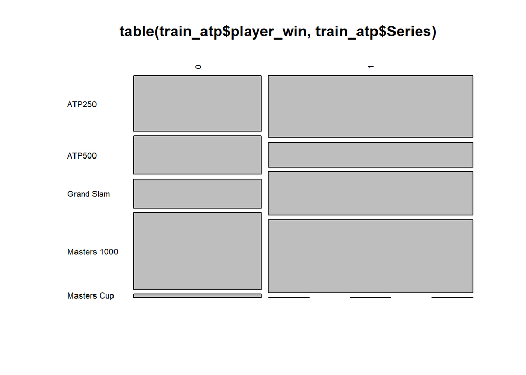

```r
plot(table(train_atp$player_win,train_atp$Series), las = 2)
```

### Court

This variable considers whether the court is indoors or outdoors. Apparently, Isner plays better when the court is outdoors, but the difference is not as noticeable.

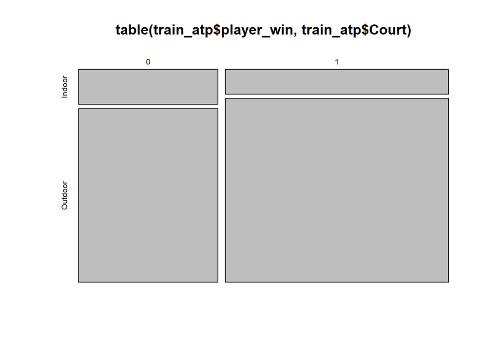

```r
plot(table(train_atp$player_win,train_atp$Court))
```

### Surface

Tennis matches are played on three different surfaces: Hard, Grass, and Clay. The differences between each surface cannot be ignored. It is no secret that many players have clear prefference of one surface over another. The most famous example may be Nadal on clay, or maybe Federer on Grass. Isner is not the exception: he seems to perform better on clay courts, while he may not be as good on hard courts.

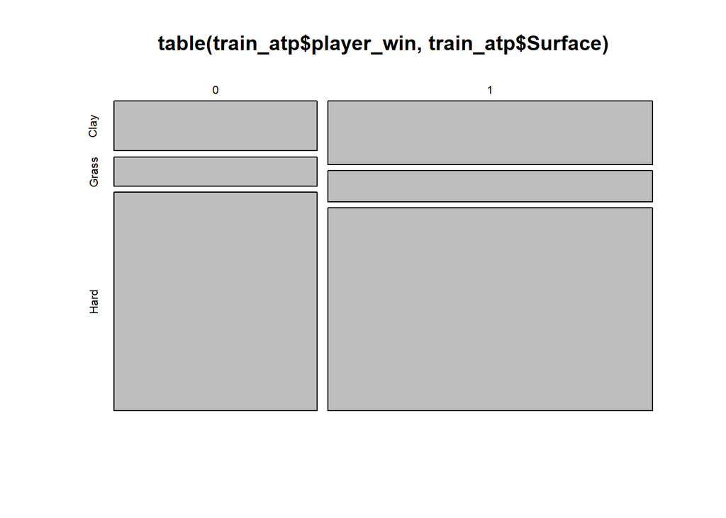

```r
plot(table(train_atp$player_win,train_atp$Surface))
```

### Round

The round is also important. It is generally easier to win in the first few rounds than it is to win later in the tournament.

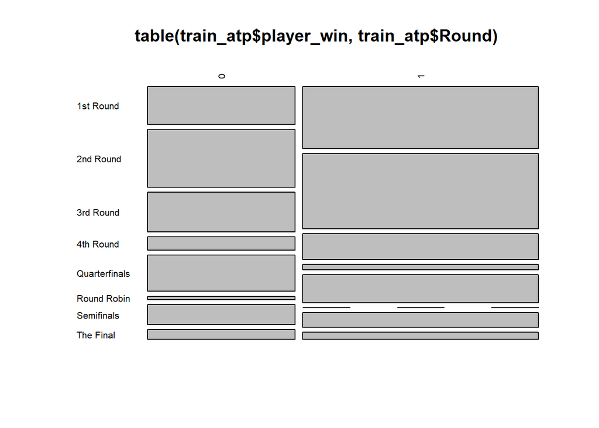

```r
plot(table(train_atp$player_win,train_atp$Round), las=2)
```

### Best of

This variable represents how many sets the player has to win in order to win the match. Most tournaments are played to the best of 3 sets, except for the Grand Slams, which are played to the best of 5 sets. While there might be some difference in the performance of the player when it comes to the best of 3 or 5 sets, I believe that this difference is encompassed better by the `Series` variable, as the information of whether it is to the best of 3 or 5 is alredy contained in said variable. Besides, `Best.of` is a categorical variable encoded as a *discrete* variable, which is generally not good practice. By not taking this variable into account, we also avoid having to solve this problem.

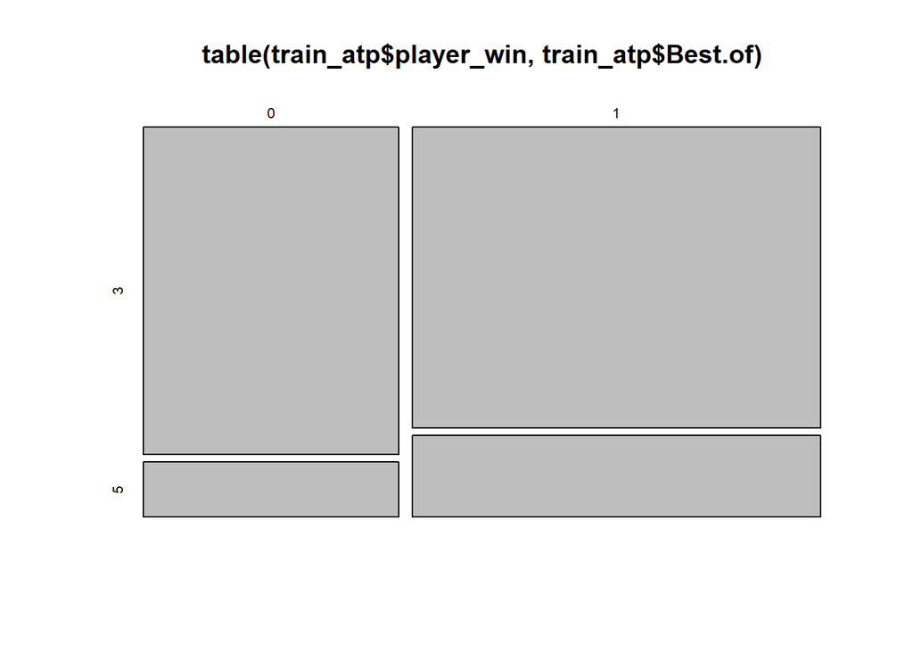

```r
plot(table(train_atp$player_win,train_atp$Best.of))
```

### Month

The month in which the match takes place seems to be of some relevance:

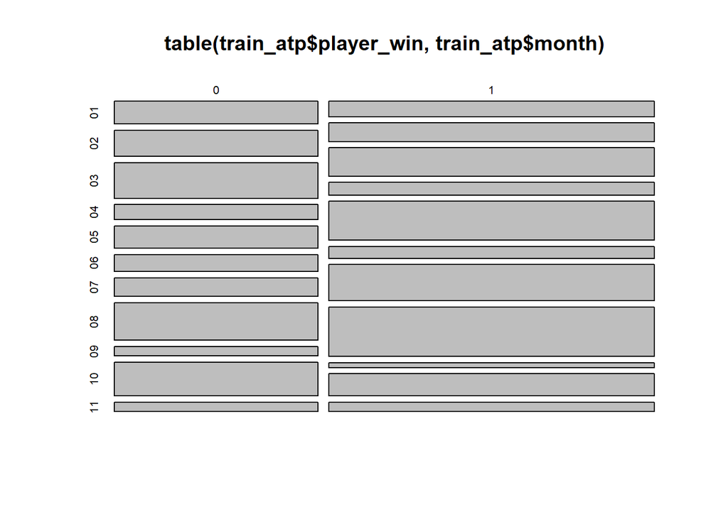

```r
plot(table(train_atp$player_win,train_atp$month))
```

However, when inspecting the data a bit further, we can see that the information is once again “contained” in another variable: `Surface`. This is because there are tennis seasons in which all the tournaments played are on one specific surface. There is little overlapping. Therefore we can dispose of this variable as well.

```r
table(train_atp$month, train_atp$Surface)
```

```
##
##      Clay Grass Hard
##   01    0     0   25
##   02    1     0   29
##   03    0     0   43
##   04   16     0    3
##   05   45     0    0
##   06    4    15    0
##   07    0    20   21
##   08    0     0   62
##   09    1     0    8
##   10    0     0   37
##   11    0     0   13
```

### Points and Rank

The variables `Rank_Player` and `Rank_Rival` gives us the world rank of Isner and his rival. While `Rank_Player` gives us little information, `Rank_Rival` seems to have some significance. It makes sense that the “lower” the rank of the rival, the easier it is to defeat him. But here we have to be careful: a low value in the rank is a high ranking; that is, the highest rank is 1, which in reality is the lowest value the variable `Rank_Rival` can take. Since the rank can take very big values, we will be using the logarithm of this value.

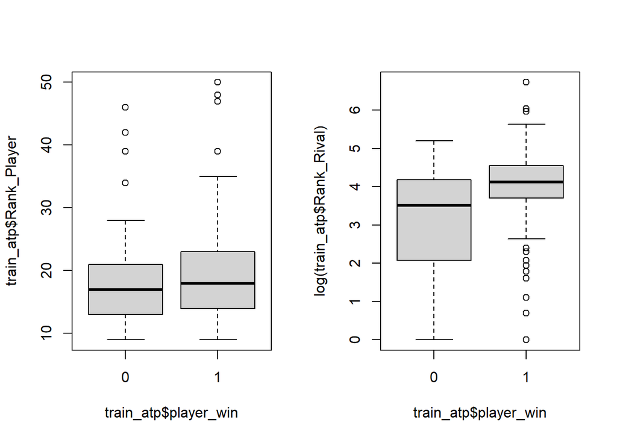

```r
par(mfrow = c(1, 2))
boxplot(train_atp$Rank_Player~train_atp$player_win)
boxplot(log(train_atp$Rank_Rival)~train_atp$player_win)
```

The analysis of `Pts_Player` and `Pts_Rival` is very similar: apparently, the points of the rival matter more than the points the player we are analyzing has. This time, however, the fewer the points the rival has, the easier it is to beat him. This makes sense because fewer points are associated with a “lower” ranking (a higher number of the `Rank` variable).

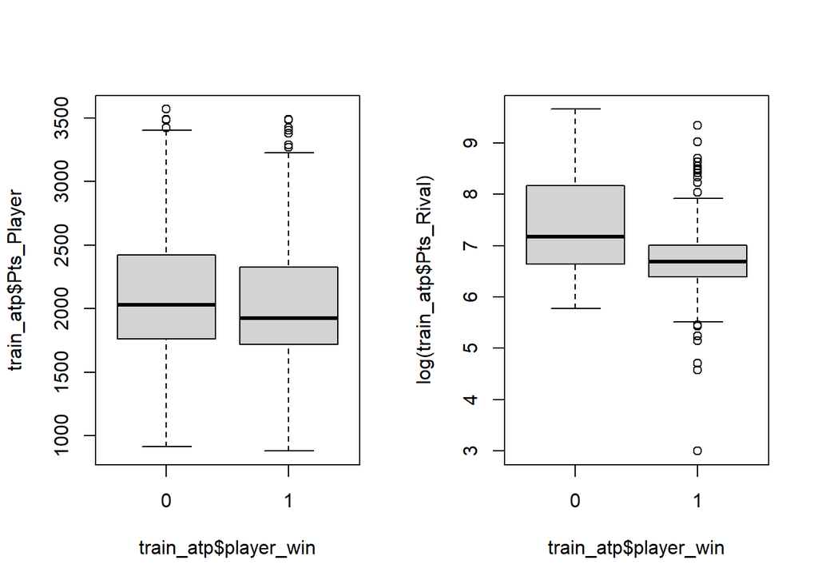

```r
par(mfrow = c(1, 2))
boxplot(train_atp$Pts_Player~train_atp$player_win)
boxplot(log(train_atp$Pts_Rival)~train_atp$player_win)
```

We have to be careful: there is some correlation between the rank and the points the players have. We can see that in the next plot:

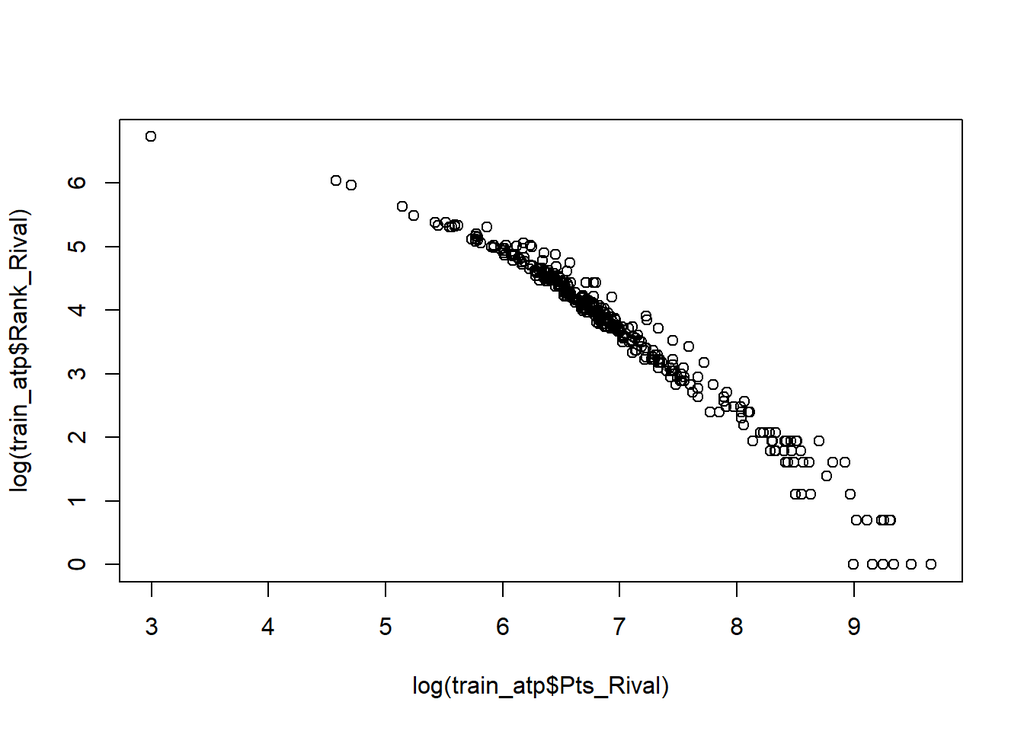

```r
plot(log(train_atp$Pts_Rival), log(train_atp$Rank_Rival))
```

### Odds

The variables `Odd_Player` and `Odd_Rival` behave in a smilar way to the rank: the higher the number, the easier it is to beat the player. This time, however, it is important to conisder both the player’s odds and the rival’s odds, as can be seen in the next plot: when `Odd_Player` is higher, Isner tends to lose, and when `Odd_Rival` is higher, Isner tends to win.

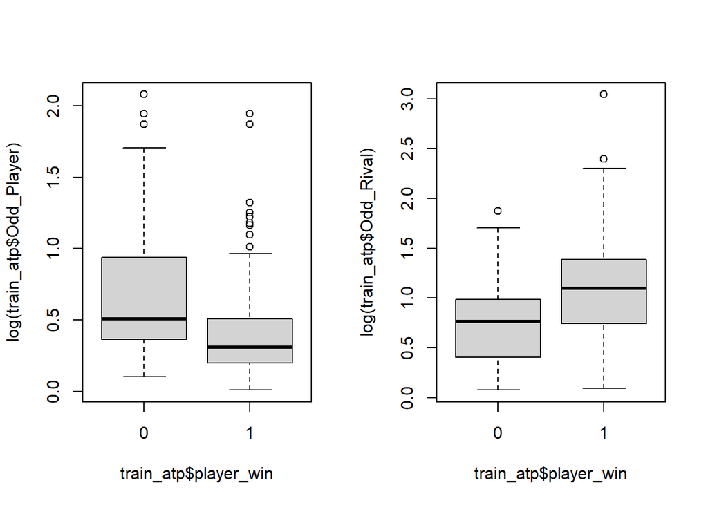

```r
par(mfrow = c(1, 2))
boxplot(log(train_atp$Odd_Player)~train_atp$player_win)
boxplot(log(train_atp$Odd_Rival)~train_atp$player_win)
```

Since the database does not provide information on how this variable was calculated, we can assume that it has a bit to do with the rank of each player or the points he has:

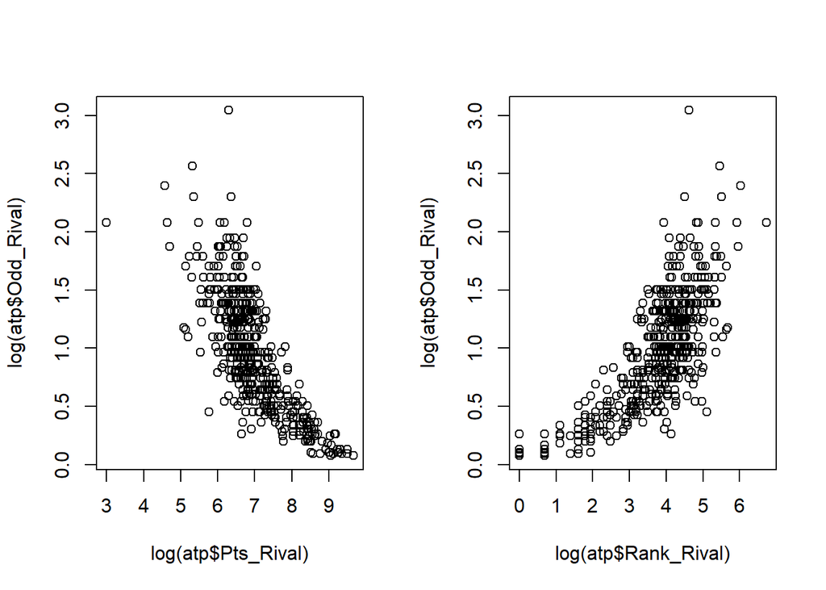

```r
par(mfrow = c(1, 2))
plot(log(atp$Pts_Rival), log(atp$Odd_Rival))
plot(log(atp$Rank_Rival), log(atp$Odd_Rival))
```

## Logistic regression

As we made in the [Case Study IV](https://halweb.uc3m.es/esp/Personal/personas/causin/eng/Bayes.Data.Science/Case4plus.html), we assume a logistic regression for this problem. We set $y_i = 1$ if Isner won the $i$-th match and $0$ otherwise. Therefore,

$$y_i \mid p_i \sim
\textrm{Bernoulli}(p_i),$$
where $p_i$ is the probability that Isner will win the $i$-th match such that
$$\log{\frac{p_i}{1+p_i}} = \beta_0 + \beta_1 x_1^i
+ \cdots + \beta_r x_r^i$$
where $x_j^i$ is the value the $j$-th predictor takes for the $i$-th match and $r$ is the number of predictors.

```r
library(MCMCpack)
out <- MCMClogit(player_win ~ Surface + log(Pts_Rival) +
                   log(Odd_Rival) + log(Odd_Player), data=train_atp,
                 burnin=1000, mcmc=21000, thin=10)
```

We could obtain the trace plots for each $\beta_j$ using `plot(out)`, but the plot won’t fit here. We can, however, obtain the posterior means, standard deviations and credible intervals with

```r
summary(out)
```

```
##
## Iterations = 1001:21991
## Thinning interval = 10
## Number of chains = 1
## Sample size per chain = 2100
##
## 1. Empirical mean and standard deviation for each variable,
##    plus standard error of the mean:
##
##                    Mean     SD Naive SE Time-series SE
## (Intercept)      3.1073 1.9282 0.042077        0.05145
## SurfaceGrass    -0.8104 0.4889 0.010668        0.01493
## SurfaceHard     -0.5782 0.3284 0.007167        0.01060
## log(Pts_Rival)  -0.4333 0.2738 0.005976        0.00902
## log(Odd_Rival)   1.1030 0.5977 0.013042        0.01941
## log(Odd_Player) -0.2054 0.7854 0.017139        0.02574
##
## 2. Quantiles for each variable:
##
##                     2.5%     25%     50%     75%   97.5%
## (Intercept)     -0.63244  1.8263  3.1313  4.3973 6.87486
## SurfaceGrass    -1.73902 -1.1440 -0.7942 -0.4858 0.18170
## SurfaceHard     -1.22260 -0.7994 -0.5784 -0.3485 0.05753
## log(Pts_Rival)  -0.95587 -0.6142 -0.4441 -0.2482 0.10229
## log(Odd_Rival)  -0.05055  0.6900  1.1014  1.5156 2.26339
## log(Odd_Player) -1.79296 -0.6975 -0.2221  0.3323 1.36746
```

And we can confirm that the thinning we used was enough:

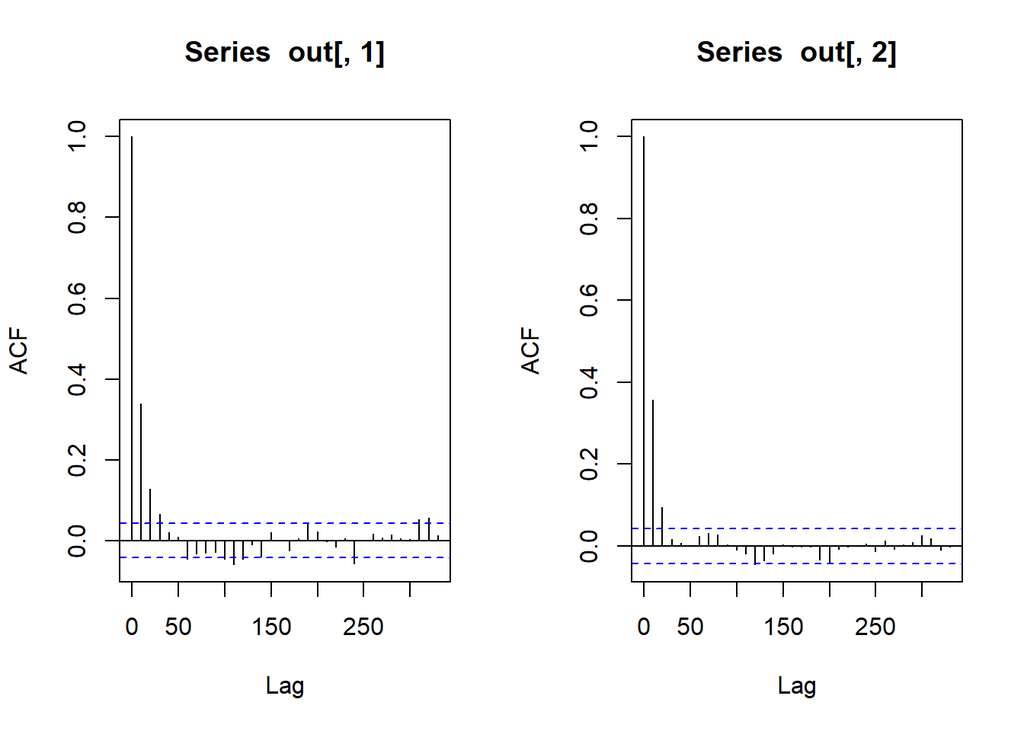

```r
par(mfrow = c(1, 2))
acf(out[,1])
acf(out[,2])
```

## Evaluating the performance of our model

### One particular match

We can obtain the posterior distribution of the win probability for a given match using the `boot` library:

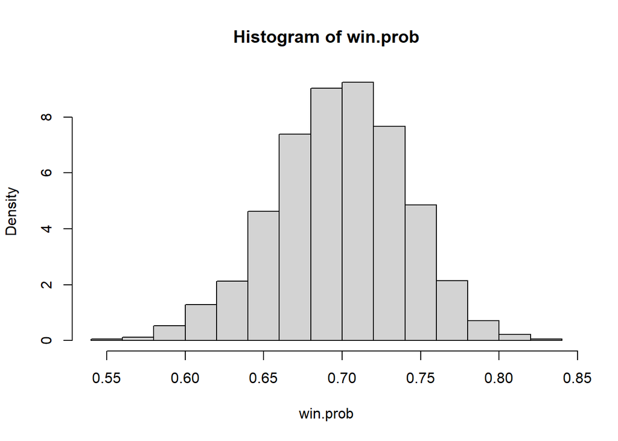

```r
new_SurfaceGrass <- ifelse(test_atp[1,]$Surface == "Grass", 1, 0)
new_SurfaceHard <- ifelse(test_atp[1,]$Surface == "Hard", 1, 0)
new_Pts_Rival <- log(test_atp[1,]$Pts_Rival)
new_Odd_Rival <- log(test_atp[1,]$Odd_Rival)
new_Odd_Player <- log(test_atp[1,]$Odd_Player)

library(boot)
win.prob <- inv.logit(out[,1] + new_SurfaceGrass*out[,2]
                      + new_SurfaceHard*out[,3] + new_Pts_Rival*out[,4]
                      + new_Odd_Rival*out[,5] + new_Odd_Player*out[,6])
hist(win.prob,freq=F)
```

```r
mean(win.prob)
```

```
## [1] 0.6983778
```

```r
median(win.prob)
```

```
## [1] 0.6996517
```

```r
quantile(win.prob,c(0.025,0.975))
```

```
##      2.5%     97.5%
## 0.6098645 0.7766246
```

The model seems to be pretty confident that Isner will win this match. To confirm:

```r
test_atp[1,]$player_win
```

```
## [1] 1
```

Isner, in fact, won that match. But this is not enough to say that the model is good: we have to evaluate with not just the first observation in our `test_atp` dataset, but all of them.

### Every match in our test dataset

```r
new_SurfaceGrass <- ifelse(test_atp$Surface == "Grass", 1, 0)
new_SurfaceHard <- ifelse(test_atp$Surface == "Hard", 1, 0)
new_Pts_Rival <- log(test_atp$Pts_Rival)
new_Odd_Rival <- log(test_atp$Odd_Rival)
new_Odd_Player <- log(test_atp$Odd_Player)

correct_losses <- 0
total_losses <- 0
correct_wins <- 0
total_wins <- 0

for (i in 1:nrow(test_atp)) {
  win.prob <- inv.logit(out[,1] + new_SurfaceGrass[i]*out[,2]
                      + new_SurfaceHard[i]*out[,3] + new_Pts_Rival[i]*out[,4]
                      + new_Odd_Rival[i]*out[,5] + new_Odd_Player[i]*out[,6])

  # If the model thinks it is a loss, we count
  if (quantile(win.prob, 0.975) < 0.5) {
    if (test_atp[i,]$player_win == 0) {
      correct_losses <- correct_losses + 1
    }
    total_losses <- total_losses + 1
  }

  # If the model thinks it is a win, we count
  if (quantile(win.prob, 0.025) > 0.5) {
    if (test_atp[i,]$player_win == 1) {
      correct_wins <- correct_wins + 1
    }
    total_wins <- total_wins + 1
  }
}

print(paste("Correct losses ratio:", correct_losses / total_losses))
```

```
## [1] "Correct losses ratio: 0.647058823529412"
```

```r
print(paste("Correct wins ratio:", correct_wins / total_wins))
```

```
## [1] "Correct wins ratio: 0.773809523809524"
```

```r
print(paste("Total hit ratio:", (correct_wins + correct_losses) /
              (total_wins + total_losses)))
```

```
## [1] "Total hit ratio: 0.752475247524752"
```

For a sports guess, the ratios don’t seem to be that bad. At least it is a better guess than to simply bet in favor of Isner all the time. The question now is how many times is the model so “sure” of the outcome of the match?

```r
(total_losses + total_wins) / nrow(test_atp)
```

```
## [1] 0.6824324
```

This ratio is a bit small. The model only takes a guess less than 70% of the time. The good thing is we can lower our standards and force it to take a guess all of the time, or as much as we want. We could repeat the previous analysis using the posterior mean instead of quantiles:

```r
correct_losses <- 0
total_losses <- 0
correct_wins <- 0
total_wins <- 0

for (i in 1:nrow(test_atp)) {
  win.prob <- inv.logit(out[,1] + new_SurfaceGrass[i]*out[,2]
                      + new_SurfaceHard[i]*out[,3] + new_Pts_Rival[i]*out[,4]
                      + new_Odd_Rival[i]*out[,5] + new_Odd_Player[i]*out[,6])

  # If the model thinks it is a loss, we count
  if (mean(win.prob) < 0.5) {
    if (test_atp[i,]$player_win == 0) {
      correct_losses <- correct_losses + 1
    }
    total_losses <- total_losses + 1
  }

  # If the model thinks it is a win, we count
  if (mean(win.prob) >= 0.5) {
    if (test_atp[i,]$player_win == 1) {
      correct_wins <- correct_wins + 1
    }
    total_wins <- total_wins + 1
  }
}

print(paste("Correct losses ratio:", correct_losses / total_losses))
```

```
## [1] "Correct losses ratio: 0.6"
```

```r
print(paste("Correct wins ratio:", correct_wins / total_wins))
```

```
## [1] "Correct wins ratio: 0.731481481481482"
```

```r
print(paste("Total hit ratio:", (correct_wins + correct_losses) /
              (total_wins + total_losses)))
```

```
## [1] "Total hit ratio: 0.695945945945946"
```

```r
(total_losses + total_wins) / nrow(test_atp)
```

```
## [1] 1
```

It is no surprise that every ratio went down, but maybe not as much. It still is a better guess than to simply bet in favor of Isner all the time.

## Comparing results with classical logistic regression

```r
classic <- glm(player_win ~ Surface + log(Pts_Rival) + log(Odd_Rival) +
                 log(Odd_Player), data=train_atp, family = "binomial")
summary(classic)
```

```
##
## Call:
## glm(formula = player_win ~ Surface + log(Pts_Rival) + log(Odd_Rival) +
##     log(Odd_Player), family = "binomial", data = train_atp)
##
## Deviance Residuals:
##     Min       1Q   Median       3Q      Max
## -2.0201  -1.0287   0.6437   0.8864   1.9617
##
## Coefficients:
##                 Estimate Std. Error z value Pr(>|z|)
## (Intercept)       3.0554     1.9754   1.547   0.1219
## SurfaceGrass     -0.7701     0.4804  -1.603   0.1089
## SurfaceHard      -0.5432     0.3241  -1.676   0.0937 .
## log(Pts_Rival)   -0.4289     0.2771  -1.548   0.1217
## log(Odd_Rival)    1.0762     0.6002   1.793   0.0730 .
## log(Odd_Player)  -0.1927     0.7759  -0.248   0.8038
## ---
## Signif. codes:  0 '***' 0.001 '**' 0.01 '*' 0.05 '.' 0.1 ' ' 1
##
## (Dispersion parameter for binomial family taken to be 1)
##
##     Null deviance: 457.14  on 342  degrees of freedom
## Residual deviance: 400.59  on 337  degrees of freedom
## AIC: 412.59
##
## Number of Fisher Scoring iterations: 4
```

```r
pred <- predict(classic, newdata = test_atp, type = "response") > 0.5
H <- table(pred, test_atp$player_win)
sum(diag(H)) / sum(H)
```

```
## [1] 0.6959459
```

We get a very similar hit ratio!